# Model Output

Weiji Su, Rhonda Szczesniak, Eleni-Rosalina Andrinopoulou

January 24, 2019

# 1 CF Data

In this analysis, there are 30811 subjects and 1215171 observations. We assume for each model that the data are missing at random, except for the joint longitudinal-survival model. The response variable is GLI FEV1 (% predicted) named “y” in data and time scale is patients’ age at visit. Age is expressed in years.

```r
summary(datan[,c( "y","Age")])
```

```
##        y                Age
##  Min.   :  4.281   Min.   : 6.00
##  1st Qu.: 49.132   1st Qu.:12.42
##  Median : 71.717   Median :17.73
##  Mean   : 69.729   Mean   :19.80
##  3rd Qu.: 89.955   3rd Qu.:24.97
##  Max.   :149.891   Max.   :76.65
```

In the following report, we investigate three commonly used structures in CF FEV1 analysis. These include the linear mixed-effect model (LME), Generalized Estimating Equations (GEE) and joint modelling (JM). For the LME models, we include different combinations of random effects, splines and correlation structures as used in published CF studies (Section 2). We examine published GEE models combined with additional features for linearity/non-linearity (Section 3). We fit a joint model with the linear/non-linear structure from the LME models in Section 2.

All the models are adjusted by patients’ birth year and age at diagnosis. The standardized birth year is used in the model by the mean = 1990 and sd=10 in the model, where 0 represents as the year 1990 and 1 standard unit represents 10 years apart from 1990.

# 2 Linear Mixed-Effect Model (LME)

## 2.1 LME Model with Random Intercept

### 2.1.1 Assumptions

Average evolution: A linear evolution is assumed over time.

Patient-specific evolution: A linear evolution is assumed over time. We assume that each patient may start from a different time point but all patients have the same evolution over time.

### 2.1.2 Model Estimation

```
## [1] "AIC =  9363158"
```

```
## [1] "BIC =  9363230"
```

```
## Random effects:
##  Formula: ~1 | eDWID
##         (Intercept) Residual
## StdDev:    1.986958        1
```

|  | Value | Std.Error | DF | t-value | p-value |
| --- | --- | --- | --- | --- | --- |
| (Intercept at age 6) | 95.181 | 0.157 | 1184359 | 664.748 | 0 |
| Age | -1.724 | 0.003 | 1184359 | -576.668 | 0 |
| DOB_Year | -1.209 | 0.107 | 30808 | -11.338 | 0 |
| Age_Diag | 0.750 | 0.033 | 30808 | 23.014 | 0 |

As the estimation of coefficient for ‘Age’ is around -1.724 % predicted/year, this means for one year increase in age, FEV1 is decreasing by 1.7240185 (unit % predicted).

### 2.1.3 Model Inference

We can calculate the population-level evolution (left) and rate of change (right) over time. As we have assumed a linear evolution, the left figure shows a straight line, corresponding to a linear estimated fit. The rate of change is calculated by taking first derivative of the model equation over time. This model estimates the rate of change in FEV1 as constant over different ages as -1.724.

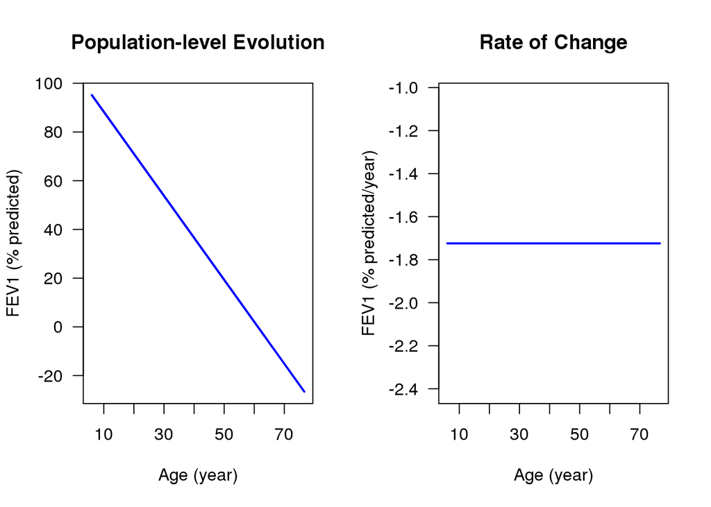

### 2.1.4 Model Diagnosis

Here we are doing model diagnosis by checking model residuals.

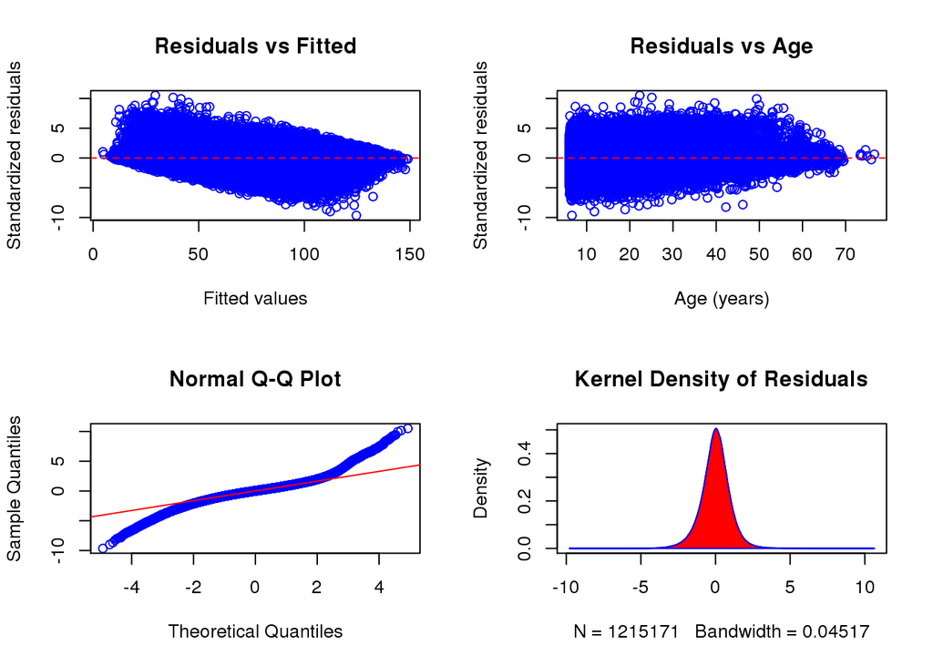

## 2.2 LME Model with Random Intercept and Slope

### 2.2.1 Assumptions

Average evolution: A linear evolution is assumed over time.

Patient-specific evolution: A linear evolution is assumed over time. We assume that each patient may start from a different time point but all patients have different evolution over time.

### 2.2.2 Model Estimation

```
## [1] "AIC =  9044784"
```

```
## [1] "BIC =  9044881"
```

```
## Random effects:
##  Formula: ~Age | eDWID
##  Structure: General positive-definite, Log-Cholesky parametrization
##             StdDev    Corr
## (Intercept) 3.6706021 (Intr)
## Age         0.2116486 -0.758
## Residual    1.0000000
```

|  | Value | Std.Error | DF | t-value | p-value |
| --- | --- | --- | --- | --- | --- |
| (Intercept at age 6) | 93.479 | 0.234 | 1184359 | 436.162 | 0 |
| Age | -1.627 | 0.013 | 1184359 | -129.281 | 0 |
| DOB_Year | 2.178 | 0.127 | 30808 | 17.138 | 0 |
| Age_Diag | 0.489 | 0.036 | 30808 | 13.595 | 0 |

### 2.2.3 Model Inference

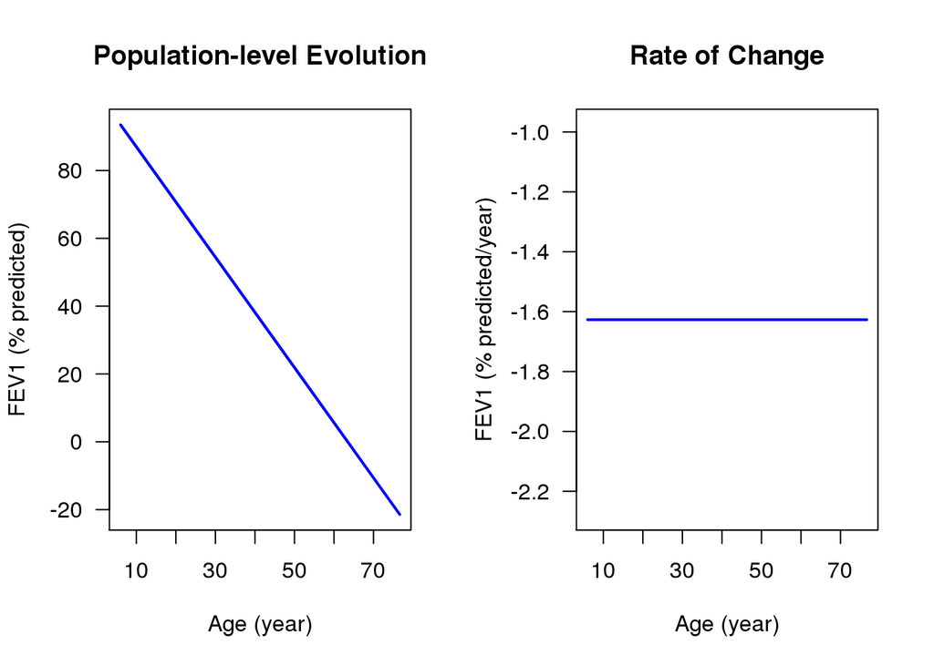

### 2.2.4 Model Diagnosis

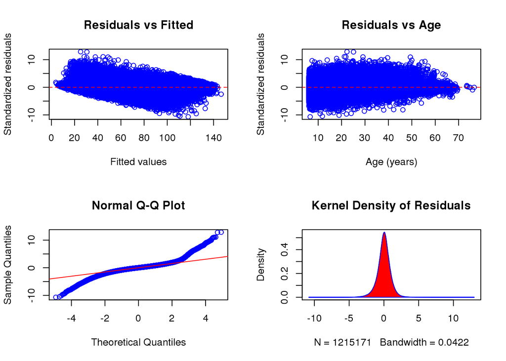

## 2.3 LME Model with 5-knot Natural Spline

### 2.3.1 Assumptions

Average evolution: A non-linear evolution (assuming cubic natural splines) is assumed over time.

Patient-specific evolution: A non-linear evolution (assuming cubic natural splines) is assumed over time. A diagonal variance covariance matrix for the random effect is assumed. This means that the random effects are not correlated.

This spline LME model is fitted with natural splines used diagonal matrix for covaraince matrix with assumption no correlation between splines and intercept and knots are located at age.

### 2.3.2 Model Estimation

```
## [1] "Knots location (at age): 9.8, 13.5, 17.3, 21.4, 31.3"
```

```
## [1] "AIC =  8928518"
```

```
## [1] "BIC =  8928723"
```

```
## Random effects:
##  Formula: ~ns1 + ns2 + ns3 + ns4 + ns5 + ns6 | eDWID
##  Structure: Diagonal
##         (Intercept)      ns1      ns2      ns3      ns4       ns5      ns6
## StdDev:    1.983959 2.054288 2.390781 3.480577 6.222577 0.3581522 3.237815
##         Residual
## StdDev:        1
```

|  | Value | Std.Error | DF | t-value | p-value |
| --- | --- | --- | --- | --- | --- |
| (Intercept at age 6) | 89.166 | 0.196 | 1184354 | 448.386 | 0 |
| ns1 | -10.042 | 0.174 | 1184354 | -57.596 | 0 |
| ns2 | -12.318 | 0.217 | 1184354 | -56.744 | 0 |
| ns3 | -28.876 | 0.310 | 1184354 | -93.152 | 0 |
| ns4 | -48.387 | 0.598 | 1184354 | -80.958 | 0 |
| ns5 | -63.192 | 0.707 | 1184354 | -89.390 | 0 |
| ns6 | -76.379 | 1.169 | 1184354 | -65.319 | 0 |
| DOB_Year | 2.146 | 0.142 | 30808 | 15.076 | 0 |
| Age_Diag | 0.685 | 0.034 | 30808 | 20.184 | 0 |

### 2.3.3 Model Inference

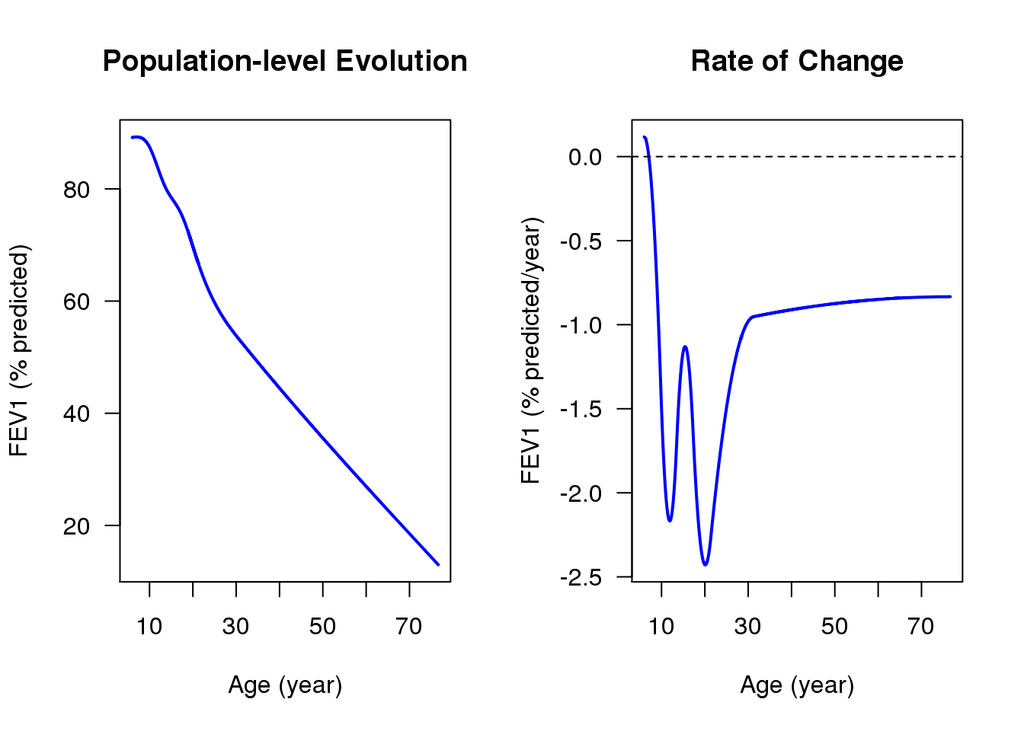

### 2.3.4 Model Diagnosis

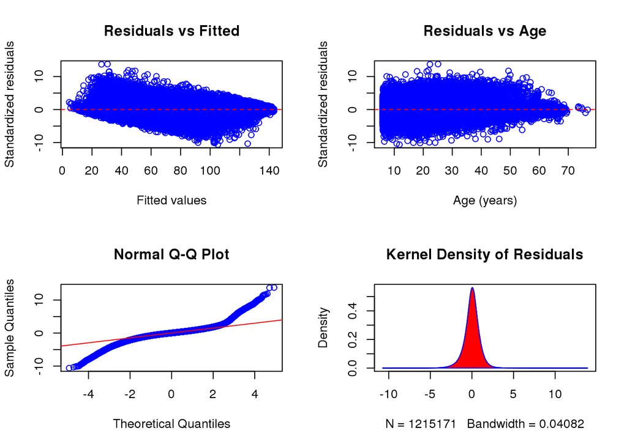

## 2.4 Linear Random Intercept with Exponential Correlation

### 2.4.1 Assumptions

Average evolution: A linear mean evolution is assumed over time.

Patient-specific evolution: A linear evolution is assumed over time. We assume that each patient may start from a different time point but all patients have the same evolution over time. Correlation structure: exponential correlation function. This means that the subject variance increases exponentially with age.

### 2.4.2 Model Estimation

```
## [1] "AIC =  8833761"
```

```
## [1] "BIC =  8833857"
```

```
## Random effects:
##  Formula: ~1 | eDWID
##         (Intercept) Residual
## StdDev:   0.4621876        1
```

```
## Correlation Structure: Exponential spatial correlation
##  Formula: ~Age | eDWID
##  Parameter estimate(s):
##      range     nugget
## 18.0416473  0.1210444
```

|  | Value | Std.Error | DF | t-value | p-value |
| --- | --- | --- | --- | --- | --- |
| (Intercept at age 6) | 89.586 | 0.270 | 1184359 | 355.155 | 0 |
| Age | -1.287 | 0.012 | 1184359 | -110.003 | 0 |
| DOB_Year | 1.919 | 0.140 | 30808 | 13.729 | 0 |
| Age_Diag | 0.705 | 0.031 | 30808 | 22.438 | 0 |

### 2.4.3 Model Inference

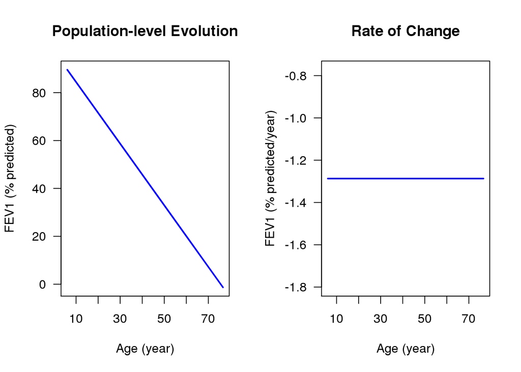

### 2.4.4 Model Diagnosis

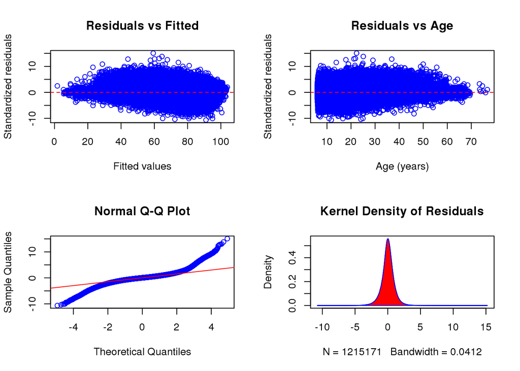

## 2.5 Spline Random Intercept with Exponential Correlation

### 2.5.1 Assumptions

Average evolution: A non-linear evolution (assuming power-truncated splines) is assumed over time.

Patient-specific evolution: A linear evolution is assumed over time and each patient may start at different time point

Correlation structure: exponential correlation function. This means that the subject variance increases exponentially with age.

### 2.5.2 Model Estimation

```
## [1] "Knots location (at age): 9.8, 13.5, 17.3, 21.4, 31.3"
```

```
## [1] "AIC =  8829987"
```

```
## [1] "BIC =  8830143"
```

```
## Random effects:
##  Formula: ~1 | eDWID
##         (Intercept) Residual
## StdDev:   0.5379792        1
```

```
## Correlation Structure: Exponential spatial correlation
##  Formula: ~Age | eDWID
##  Parameter estimate(s):
##      range     nugget
## 16.2928784  0.1339253
```

|  | Value | Std.Error | DF | t-value | p-value |
| --- | --- | --- | --- | --- | --- |
| (Intercept at age 6) | 88.417 | 0.222 | 1184354 | 391.623 | 0 |
| ns1 | -9.344 | 0.200 | 1184354 | -46.751 | 0 |
| ns2 | -11.656 | 0.229 | 1184354 | -50.809 | 0 |
| ns3 | -28.694 | 0.282 | 1184354 | -101.911 | 0 |
| ns4 | -42.089 | 0.674 | 1184354 | -62.478 | 0 |
| ns5 | -43.965 | 1.077 | 1184354 | -40.815 | 0 |
| ns6 | -48.217 | 1.989 | 1184354 | -24.244 | 0 |
| DOB_Year | 2.535 | 0.139 | 30808 | 18.283 | 0 |
| Age_Diag | 0.659 | 0.031 | 30808 | 21.399 | 0 |

### 2.5.3 Model Inference

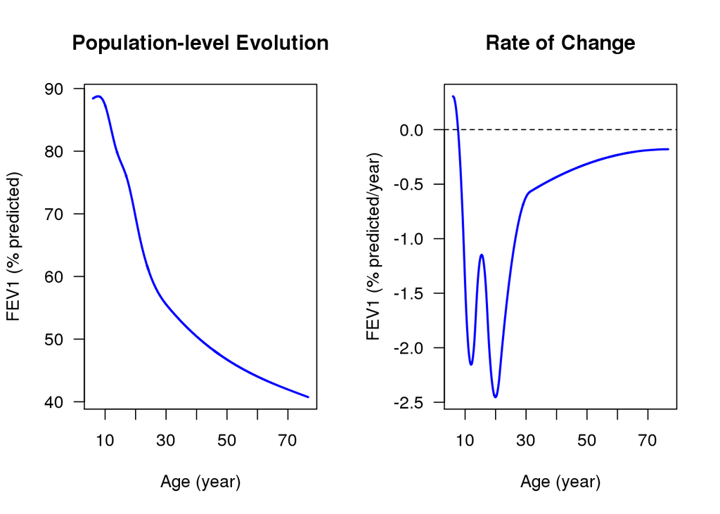

### 2.5.4 Model Diagnosis

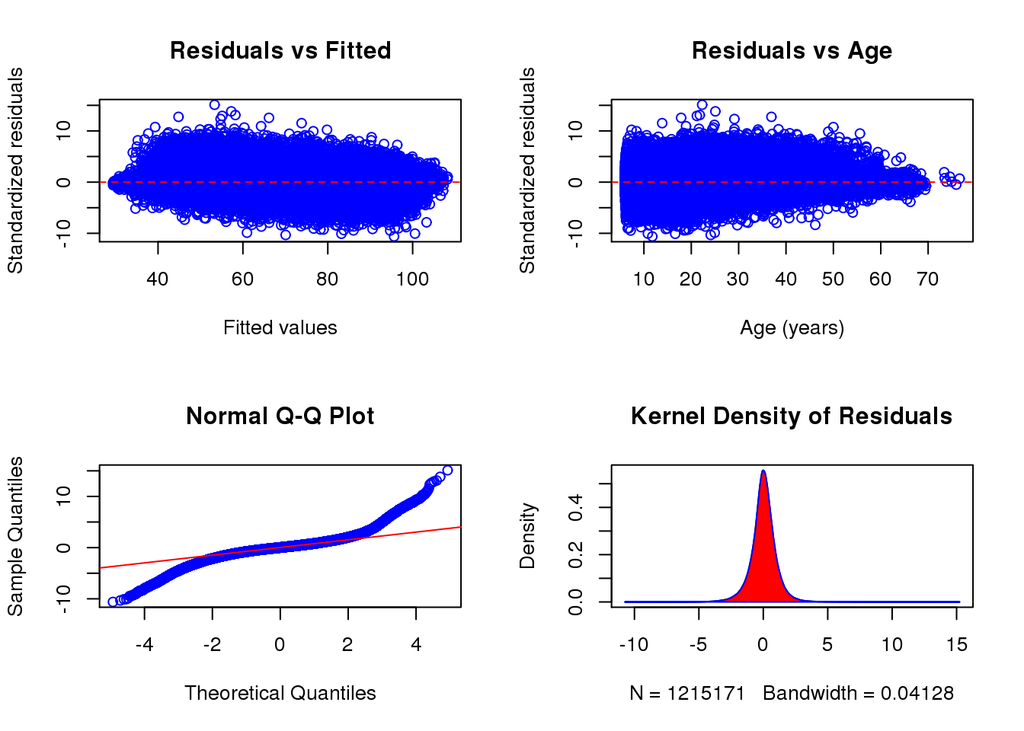

# 3 Linear Generalized Estimating Equations model (GEE)

Compared with LME models, GEE models allow for weaker distributional assumptions and are more robust to covariance misspecification. In this analysis, the average evolution (fixed-effect) structure in the GEE model was selected based on the performance of all LME models. This GEE mode is fitted with a linear structure to model the mean evolution and includes a independence correlation.

## 3.1 Assumptions

Patient-specific evolution: A linear evolution is assumed over time and each patient may start at different time point.

Correlation structure: independence correlation function.

## 3.2 Model Estimation

Coefficients:

|  | Estimate | Std.err | Wald | Pr(>\|W\|) |
| --- | --- | --- | --- | --- |
| (Intercept at age 6) | 81.464 | 0.451 | 35831.685 | 0 |
| Age | -0.851 | 0.021 | 1567.275 | 0 |
| DOB_Year | 4.313 | 0.215 | 404.237 | 0 |
| Age_Diag | 0.548 | 0.039 | 202.084 | 0 |

Estimated Scale Parameters:

|  | Estimate | Std.err |
| --- | --- | --- |
| (Intercept) | 514.245 | 3.378 |

## 3.3 Model Inference

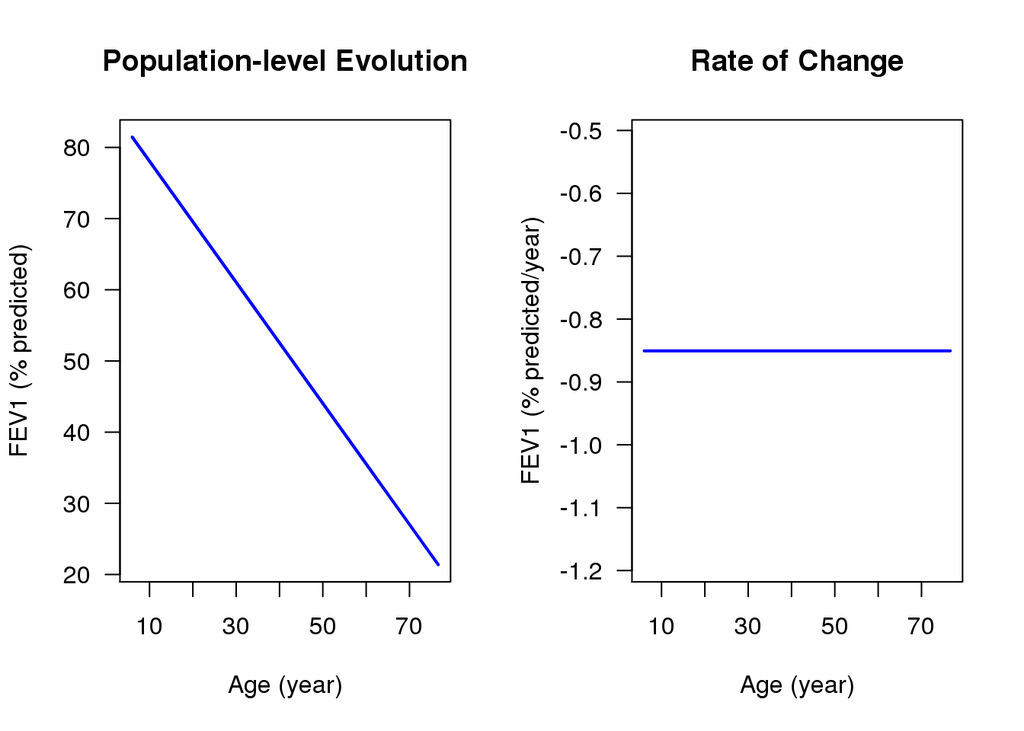

## 3.4 Model Diagnosis

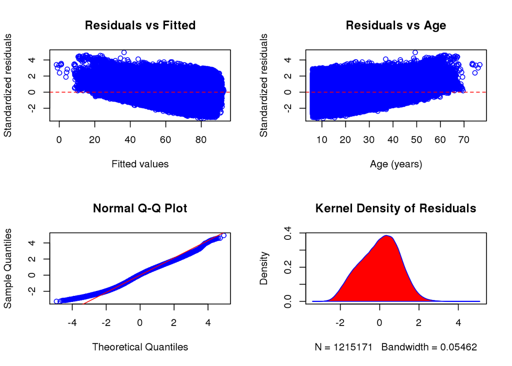

# 4 Non-linear Generalized Estimating Equations Model (GEE)

Compared with LME models, GEE models allow for weaker distributional assumptions and are more robust to covariance misspecification. In this analysis, the average evolution (fixed-effect) structure in the GEE model was selected based on the performance of all LME models. This GEE mode is fitted with a spline structure to model the mean evolution and includes a independence correlation.

## 4.1 Assumptions

Average evolution: A non-linear evolution (assuming power-truncated splines) is used over time.

Patient-specific evolution: A linear evolution is assumed over time and each patient may start at different time point.

Correlation structure: independence correlation function.

## 4.2 Model Estimation

Coefficients:

|  | Estimate | Std.err | Wald | Pr(>\|W\|) |
| --- | --- | --- | --- | --- |
| (Intercept at age 6) | 86.050 | 0.353 | 57894.807 | 0 |
| ns1 | -11.982 | 0.398 | 907.829 | 0 |
| ns2 | -15.629 | 0.476 | 1076.230 | 0 |
| ns3 | -27.502 | 0.536 | 2629.728 | 0 |
| ns4 | -27.640 | 1.229 | 505.552 | 0 |
| ns5 | -27.655 | 1.805 | 234.807 | 0 |
| ns6 | -25.018 | 3.313 | 57.013 | 0 |
| DOB_Year | 4.416 | 0.207 | 453.849 | 0 |
| Age_Diag | 0.506 | 0.037 | 186.475 | 0 |

Estimated Scale Parameters:

|  | Estimate | Std.err |
| --- | --- | --- |
| (Intercept) | 493.019 | 3.312 |

## 4.3 Model Inference

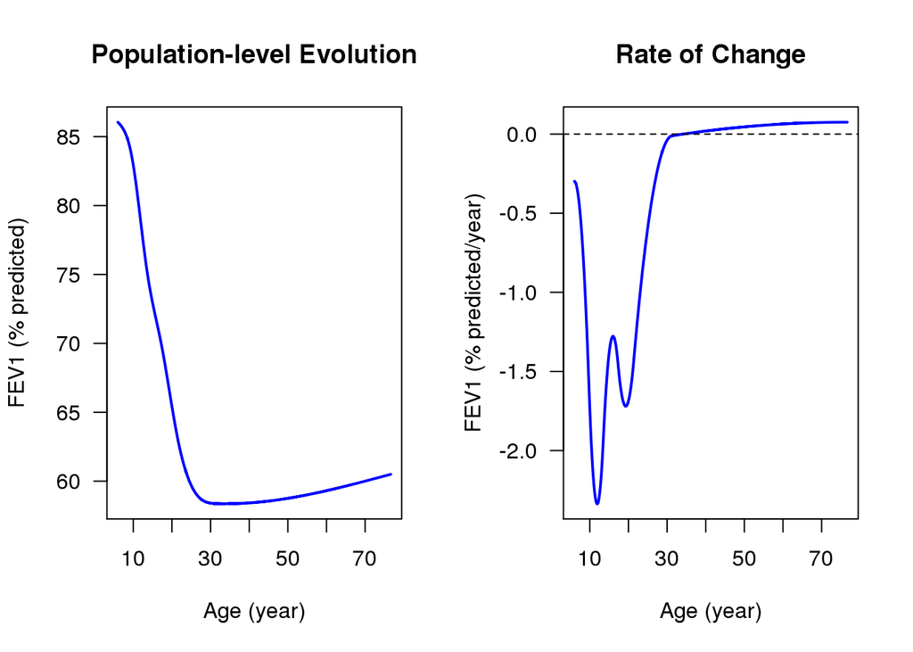

## 4.4 Model Diagnosis

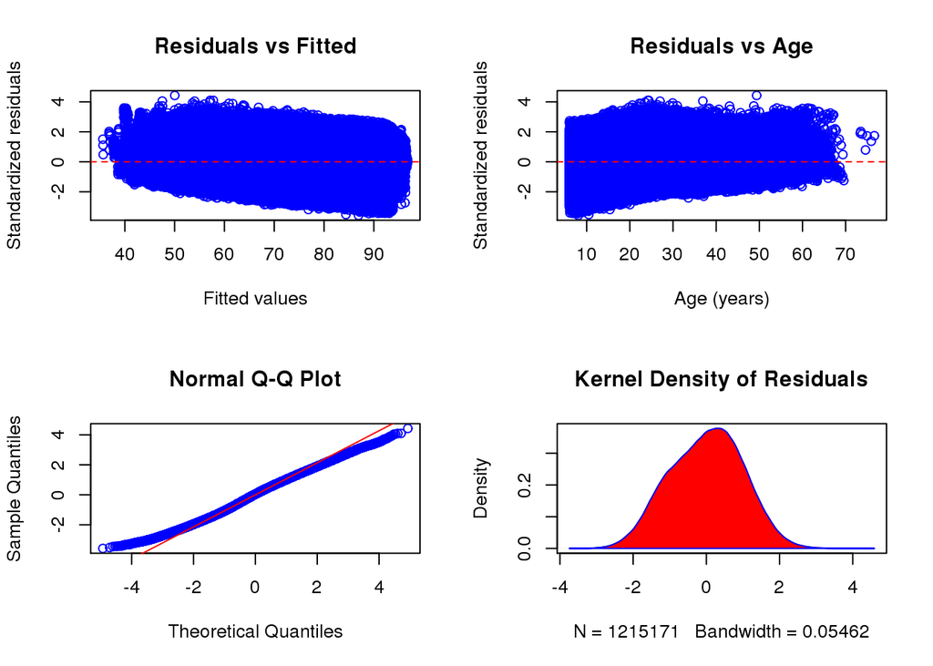

# 5 Linear Joint Model of Longitudinal FEV1(% predicted) and Survival (JM)

To fit FEV1 together with survival analysis, in order to account for missing data due to death or lung transplant, we use the linear average evolution to model the mean evolution over time for FEV1. Missing data due to death or lung transplant is accounted for by jointly modeling the FEV1 process with the survival process using a Weibul model for survival. We use a Weibull baseline risk function to fit the baseline hazard in the survival submodel. This joint model was implemented using the shared parameter framework. The shared parameters here corresponded to connecting the survival outcome with the underlying value of FEV1 and rate of change over time.

## 5.1 Assumptions

We assume that FEV1 and survival are associated over time (age). To monitor longitudinal FEV1, we apply the LME model with linear assumption; for survival, we use the Weibull survival model.

Average evolution of FEV1: A linear evolution is assumed over time.

Survival Baseline hazard: A Weibull baseline risk hazard is assumed over time at baseline.

Association: We assume the underlying value of FEV1 and rate of change over time to be associated with survival.

## 5.2 Model Estimation and Interpretation

```
## [1] "AIC =  9053199"
```

```
## [1] "BIC =  9053316"
```

Variance Components

|  | (Intercept) | Age |
| --- | --- | --- |
| (Intercept) | 1067.431 | -47.956 |
| Age | -47.956 | 3.791 |

Longitudinal Process

|  | Value | Std.Err | z-value | p-value |
| --- | --- | --- | --- | --- |
| (Intercept at age 6) | 94.043 | 0.148 | 697.852 | 0 |
| Age | -1.750 | 0.007 | -243.164 | 0 |
| DOB_Year | 0.895 | 0.068 | 13.204 | 0 |
| Age_Diag | 0.521 | 0.009 | 58.449 | 0 |

Event Process

|  | Value | p-value | Hazard Ratio | Lower | Upper |
| --- | --- | --- | --- | --- | --- |
| (Intercept) | -11.168 | 0 | 0.000 | 0.000 | 0.000 |
| DOB_Year | 0.849 | 0 | 2.338 | 2.238 | 2.442 |
| Age_Diag | -0.014 | 0 | 0.986 | 0.979 | 0.993 |
| Assoct | -0.078 | 0 | 0.925 | 0.923 | 0.926 |
| Assoct.s | -0.282 | 0 | 0.754 | 0.743 | 0.766 |
| log(shape) | 1.388 | 0 | 4.009 | 3.903 | 4.118 |

## 5.3 Model Inference

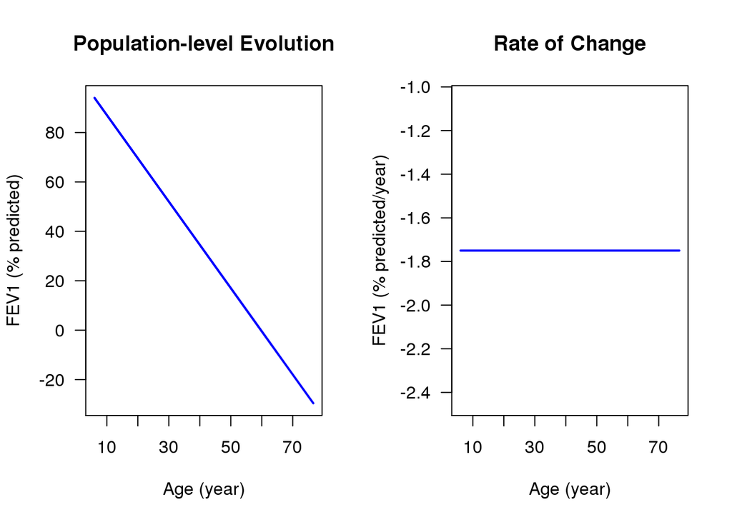

## 5.4 Model Diagnosis

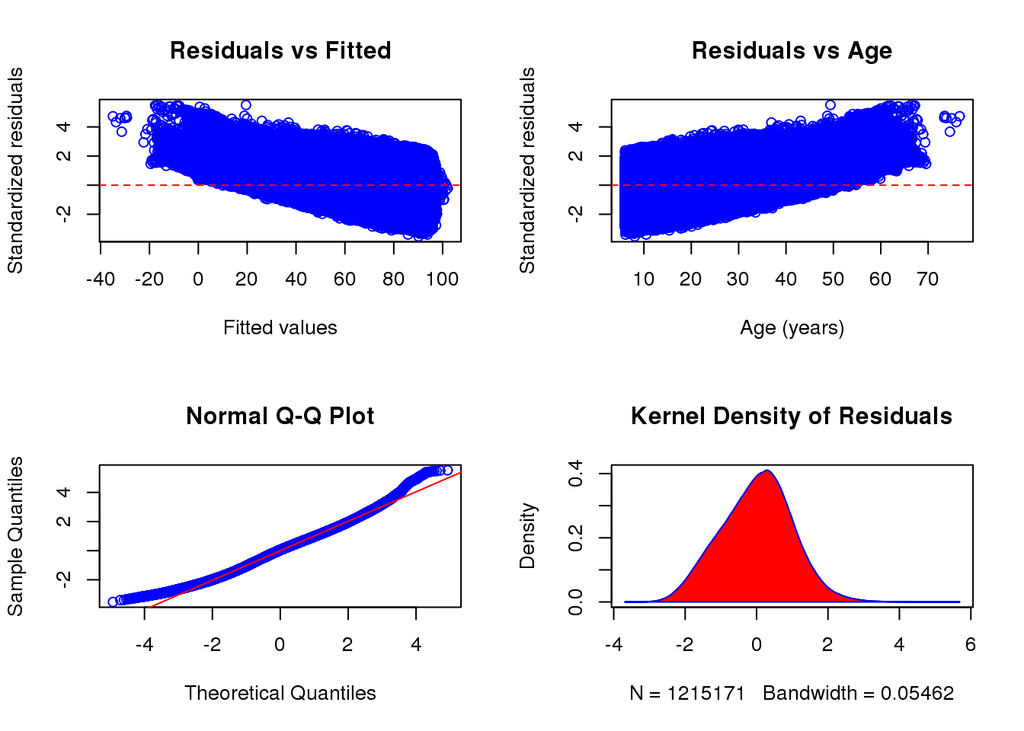

# 6 Non-linear Joint Model of Longitudinal FEV1(% predicted) and Survival (JM)

To fit FEV1 together with survival analysis, in order to account for missing data due to death or lung transplant, we use the non-linear (spline) average evolution to model the mean evolution over time for FEV1. Similar like the linear joint model, missing data due to death or lung transplant is accounted for by jointly modeling the FEV1 process with the survival process using a Weibull model for survival. We used a Weibull baseline risk function to fit the baseline hazard in the survival submodel. This joint model was implemented using the shared parameter framework. The shared parameters here corresponded to connecting the survival outcome with the underlying value of FEV1 and rate of change over time.

## 6.1 Assumptions

We assume that FEV1 and survival are associated over time (age). To monitor longitudinal FEV1, we apply the LME model with splines; for survival, we use the Weibull survival model.

Average evolution of FEV1: A non-linear evolution by spline is assumed over time.

Survival Baseline hazard: A Weibull baseline risk hazard is assumed over time at baseline.

Association: We assume the underlying value of FEV1 and rate of change over time to be associated with survival.

## 6.2 Model Estimation and Interpretation

```
## [1] "AIC =  9044960"
```

```
## [1] "BIC =  9045118"
```

Variance Components

|  | (Intercept) | Age |
| --- | --- | --- |
| (Intercept) | 1060.675 | -47.158 |
| Age | -47.158 | 3.714 |

Longitudinal Process

|  | Value | Std.Err | z-value | p-value |
| --- | --- | --- | --- | --- |
| (Intercept at age 6) | 88.902 | 0.130 | 675.486 | 0 |
| ns1 | -9.601 | 0.107 | -89.888 | 0 |
| ns2 | -13.100 | 0.134 | -98.050 | 0 |
| ns3 | -30.712 | 0.163 | -188.616 | 0 |
| ns4 | -61.311 | 0.377 | -162.551 | 0 |
| ns5 | -108.935 | 0.644 | -169.249 | 0 |
| ns6 | -149.443 | 1.108 | -134.888 | 0 |
| DOB_Year | 1.106 | 0.070 | 15.754 | 0 |
| Age_Diag | 0.489 | 0.009 | 53.045 | 0 |

Event Process

|  | Value | p-value | Hazard Ratio | Lower | Upper |
| --- | --- | --- | --- | --- | --- |
| (Intercept) | -11.177 | 0 | 0.000 | 0.000 | 0.000 |
| DOB_Year | 0.830 | 0 | 2.293 | 2.195 | 2.396 |
| Age_Diag | -0.015 | 0 | 0.985 | 0.978 | 0.992 |
| Assoct | -0.079 | 0 | 0.924 | 0.923 | 0.925 |
| Assoct.s | -0.283 | 0 | 0.754 | 0.743 | 0.764 |
| log(shape) | 1.388 | 0 | 4.008 | 3.901 | 4.118 |

## 6.3 Model Inference

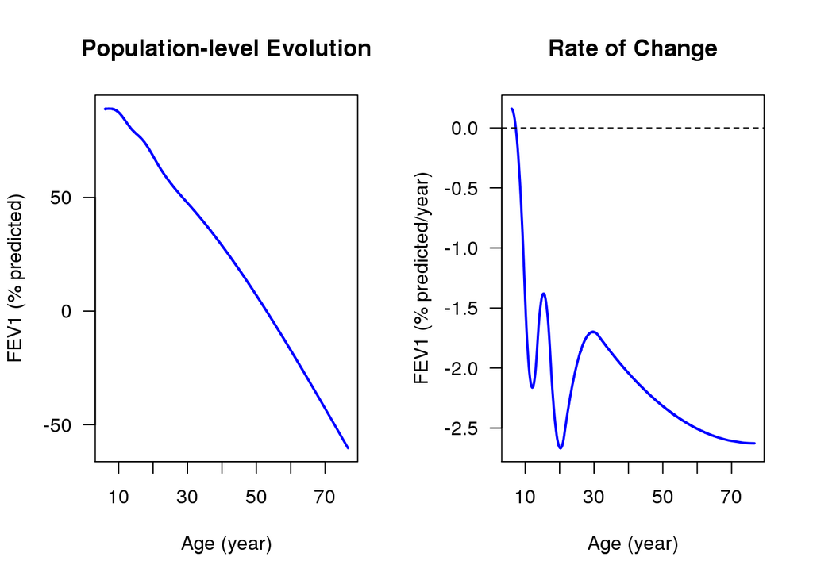

## 6.4 Model Diagnosis

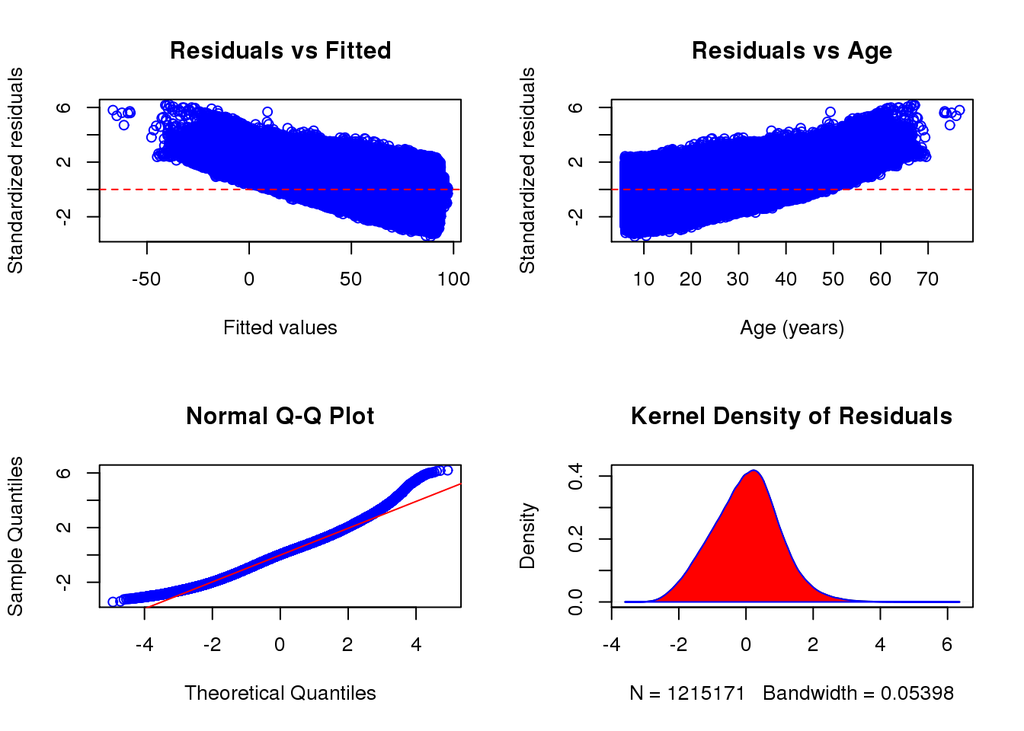

# 7 Plot Population-level FEV1 (% predicted) Estimation for All Models

| Model Name Abbreviation Name | Model Name Abbreviation Specification |
| --- | --- |
| Int | Linear evolution with random intercept |
| Int + Slope | Linear evolution with random intercept and slope |
| Spline | Non-linear evolution by using spline as both average evolution and random effect |
| Int + Corr | Linear evolution with random intercept and exponential correlation structure |
| Spline + Corr | Non-linear evolution with spline as average evolution, random intercept and exponential correlation structure |
| Lin_GEE | Linear evolution with independence correlation structure |
| Nonlin_GEE | Non-linear evolution by using spline with independence correlation structure |
| Lin_JM | Linear evolution with jointly model FEV and survival |
| Nonlin_JM | Non-linear evolution with jointly model FEV and survival |

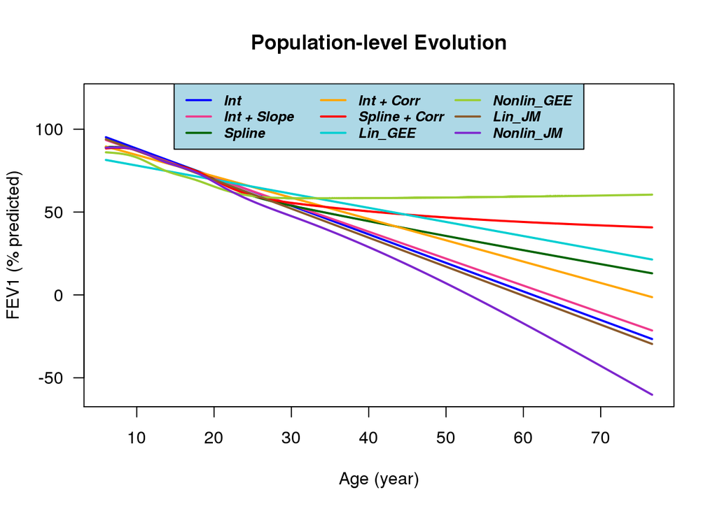

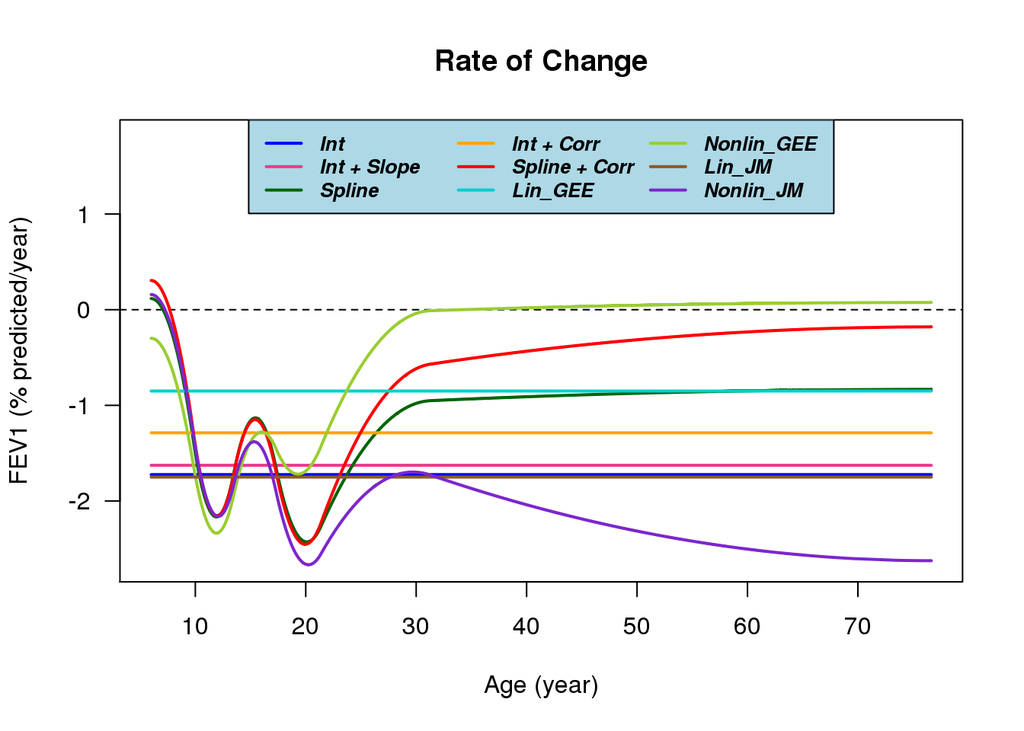

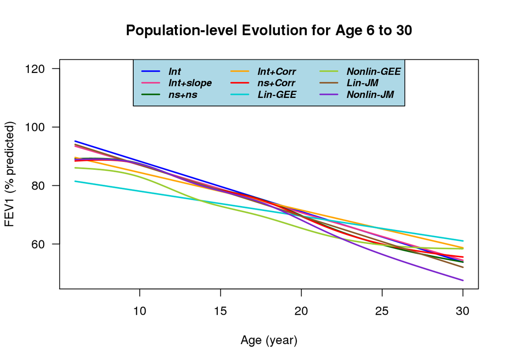

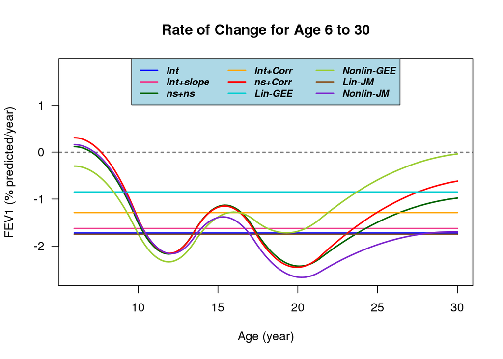